# Data Summary and EDA Report

Atalor Polycarp Ehiz

2024-11-27

# Import Data

```r
     my_data <- read.csv("brain-cancer-dataset.csv")
```

# **1. Introduction**

This report analyzes clinical and genetic data consisting of mostly children with brain cancer. The goal is to prepare the dataset for machine learning models that predict:

- **OS.Status (Overall Survival Status):** Whether a patient survived.
- **DFS.Status (Disease-Free Survival Status):** Whether a patient remained disease-free.

The analysis includes:

Preprocessing: Cleaning the data to ensure quality. Feature Selection: Identifying relevant clinical and genetic variables. Exploratory Data Analysis (EDA): Understanding relationships between variables.

# **2. Description of the Dataset**

### 2.1**Dataset Overview**

- **Number of Records:** 218
- **Number of Features:** 61
- **Missing Values:** Yes (handled during preprocessing)

### 2.2 **Variable Types**

- **Categorical Variables:** Features like Cancer.Type, Treatment, and Tumor.Type.
- **Numerical Variables:** Age-related data, mutation counts, and other clinical measurements.

# **3. Preprocessing Steps**

To ensure the dataset is clean and ready for analysis, several preprocessing steps were undertaken.

### **3.1 Handling Missing Values**

- **Numerical Variables:** Missing values were replaced with the median to preserve the data’s distribution.
- **Categorical Variables:** Missing values were replaced with “Unknown” for consistency.

```r
# Handle Missing Values
my_data <- my_data %>%
  mutate(across(where(is.numeric), ~ ifelse(is.na(.), median(., na.rm = TRUE), .))) %>%
  mutate(across(where(is.character), ~ ifelse(is.na(.), "Unknown", .))) %>%
  mutate(across(where(is.factor), ~ ifelse(is.na(.), as.character(levels(.)[1]), .)))

# Verify no missing values remain
if (sum(is.na(my_data)) > 0) {
  stop("Unresolved missing values in the dataset.")
}
```

### **3.2 Feature Cleaning**

- Column names were trimmed and standardized for compatibility with R functions.
- All categorical variables were converted into factors.

```r
# Standardize Column Names
colnames(my_data) <- trimws(colnames(my_data))
colnames(my_data) <- make.names(colnames(my_data), unique = TRUE)

# Convert Categorical Variables to Factors
my_data <- my_data %>% mutate(across(where(is.character), as.factor))
```

### **3.3 Feature Filtering**

- **Variance Filtering:** Features with low variance (<0.01) were removed as they add little information.
- **Correlation Filtering:** Features with high correlation (>0.8) were removed to reduce redundancy.

```r
# Filter Low-Variance Features
variances <- apply(my_data[, sapply(my_data, is.numeric)], 2, var, na.rm = TRUE)
data_filtered <- my_data[, variances > 0.01]

# Remove Highly Correlated Features
cor_matrix <- cor(data_filtered[, sapply(data_filtered, is.numeric)], use = "complete.obs")
high_corr <- findCorrelation(cor_matrix, cutoff = 0.8)
data_filtered <- data_filtered[, -high_corr]
```

### **3.4 Feature Selection**

```r
   # Define categorical columns
categorical_columns <- c(
  "Study.ID", "Patient.ID", "Sample.ID", "Age.Class", "BRAF_RELA.Status",
  "BRAF.Status", "BRAF.Status2", "Cancer.Predispositions", "Cancer.Type",
  "Cancer.Type.Detailed", "Chemotherapy", "Chemotherapy.Agents",
  "Chemotherapy.Type", "Clinical.Status.at.Collection.Event",
  "CTNNB1.Status", "DFS.Status", "Ethnicity", "Extent.of.Tumor.Resection",
  "External.Patient.ID", "Formulation", "H3F3A_CTNNB1.Status",
  "Initial.CNS.Tumor.Diagnosis.Related.to.OS", "Initial.Diagnosis.Type",
  "LGG_BRAF.Status", "Medical.Conditions", "Multiple.Cancer.Predispositions",
  "Multiple.Medical.Conditions", "Multiple.Tumor.Locations", "Oncotree.Code",
  "OS.Status", "Protocol.and.Treatment.Arm", "Race", "Radiation",
  "Radiation.Site", "Radiation.Type", "Sample.Annotation", "Sample.Origin",
  "Sex", "Surgery", "Treatment", "Treatment.Changed", "Treatment.Status",
  "Tumor.Location.Condensed", "Tumor.Tissue.Site", "Tumor.Type", "Updated.Grade"
)
```

Significant features were identified for both OS.Status and DFS.Status using a Chi-square test.

```r
# Chi-Square Test for Feature Selection
chi_sq_results_OS <- lapply(categorical_columns, function(col) {
  table_data <- table(my_data[[col]], my_data$OS.Status)
  if (any(dim(table_data) == 0)) {
    return(data.frame(Feature = col, p_value = NA))
  }
  test_result <- chisq.test(table_data)
  data.frame(Feature = col, p_value = test_result$p.value)
})

chi_sq_summary_OS <- do.call(rbind, chi_sq_results_OS)
significant_features_OS <- chi_sq_summary_OS %>% filter(p_value < 0.05)
```

# 4. Key Insights from EDA

### **4.1 Target Variable Distribution**

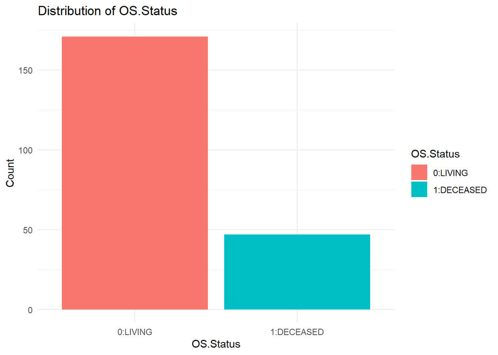

```r
# OS.Status Distribution
ggplot(my_data, aes(x = OS.Status, fill = OS.Status)) +
  geom_bar() +
  labs(title = "Distribution of OS.Status", x = "OS.Status", y = "Count") +
  theme_minimal()
```

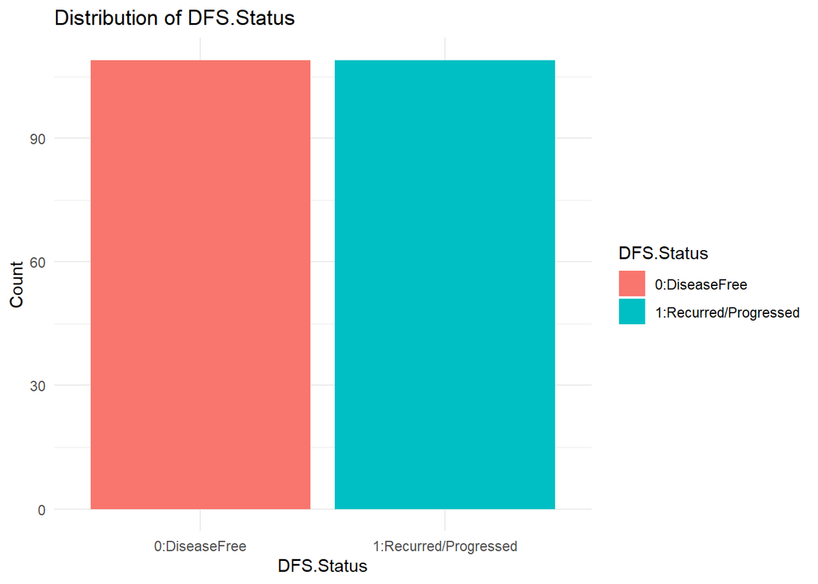

```r
# DFS.Status Distribution
ggplot(my_data, aes(x = DFS.Status, fill = DFS.Status)) +
  geom_bar() +
  labs(title = "Distribution of DFS.Status", x = "DFS.Status", y = "Count") +
  theme_minimal()
```

### *4.2 Correlation Analysis*

A heatmap was used to visualize correlations among numerical variables. Highly correlated features were excluded.

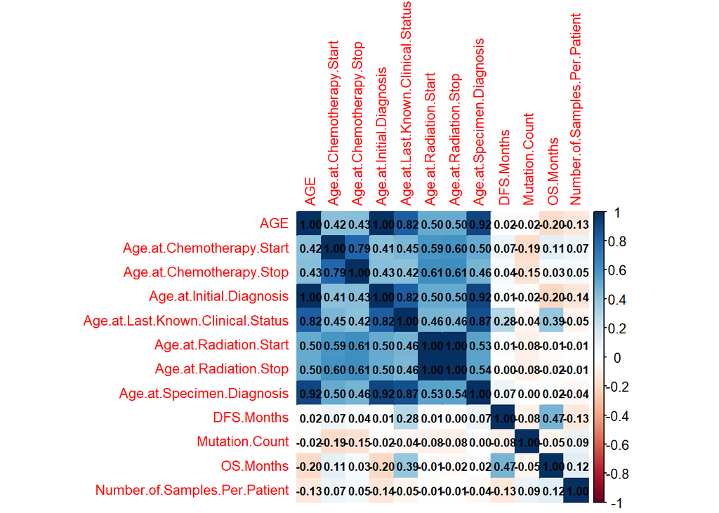

```r
# Correlation Matrix Visualization
corrplot(cor_matrix, method = "color", tl.cex = 0.8, number.cex = 0.7, addCoef.col = "black")
```

- **Insight:** Some numerical features showed high correlations and were excluded to prevent multicollinearity.

### 4.3 Selected Features

To summarize the features selected for OS.Status and DFS.Status, we present: - A Bar Plot showing the total number of features selected for each target variable. - A Table listing the features categorized as unique to each target variable or common to both.

- **Features for OS.Status & DFS.Status**

```r
# Chi-square test for OS.Status and DFS.Status
chi_sq_results_OS <- lapply(categorical_columns, function(col) {
  table_data <- table(my_data[[col]], my_data$OS.Status)
  if (any(dim(table_data) == 0)) {
    return(data.frame(Feature = col, p_value = NA))
  }
  test_result <- chisq.test(table_data)
  data.frame(Feature = col, p_value = test_result$p.value)
})

chi_sq_summary_OS <- do.call(rbind, chi_sq_results_OS)

chi_sq_results_DFS <- lapply(categorical_columns, function(col) {
  table_data <- table(my_data[[col]], my_data$DFS.Status)
  if (any(dim(table_data) == 0)) {
    return(data.frame(Feature = col, p_value = NA))
  }
  test_result <- chisq.test(table_data)
  data.frame(Feature = col, p_value = test_result$p.value)
})

chi_sq_summary_DFS <- do.call(rbind, chi_sq_results_DFS)
```

```r
# Filter significant features for OS.Status and DFS.Status
significant_features_OS <- chi_sq_summary_OS %>% filter(p_value < 0.05)
significant_features_DFS <- chi_sq_summary_DFS %>% filter(p_value < 0.05)

# Subset data for significant features
data_OS <- my_data %>% select(all_of(significant_features_OS$Feature), OS.Status)
data_DFS <- my_data %>% select(all_of(significant_features_DFS$Feature), DFS.Status)
```

```r
# Extract selected features
selected_features_OS <- colnames(data_OS)[colnames(data_OS) != "OS.Status"]
selected_features_DFS <- colnames(data_DFS)[colnames(data_DFS) != "DFS.Status"]

# Create a summary of feature counts
feature_counts <- data.frame(
  Target = c("OS.Status", "DFS.Status"),
  Features = c(length(selected_features_OS), length(selected_features_DFS)),
  Common = length(intersect(selected_features_OS, selected_features_DFS))
)
```

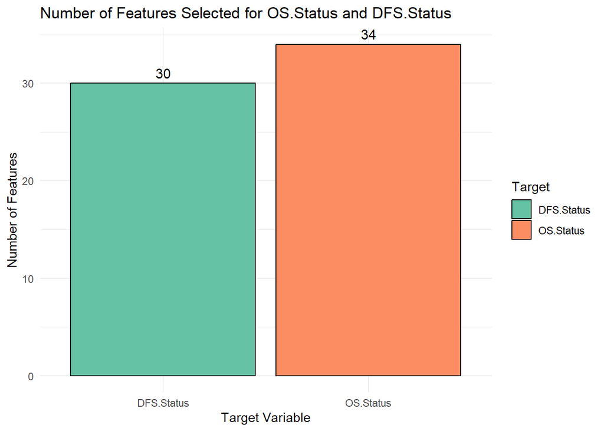

```r
# Create a bar plot
ggplot(feature_counts, aes(x = Target, y = Features, fill = Target)) +
  geom_bar(stat = "identity", position = "dodge", color = "black") +
  geom_text(aes(label = Features), vjust = -0.5, size = 4) +
  labs(
    title = "Number of Features Selected for OS.Status and DFS.Status",
    x = "Target Variable",
    y = "Number of Features"
  ) +
  theme_minimal() +
  scale_fill_brewer(palette = "Set2")
```

- **Union of Features:**

```r
# Categorize features
feature_categories <- data.frame(
  Feature = union(selected_features_OS, selected_features_DFS),
  Category = ifelse(
    union(selected_features_OS, selected_features_DFS) %in% intersect(selected_features_OS, selected_features_DFS), "Both",
    ifelse(union(selected_features_OS, selected_features_DFS) %in% selected_features_OS, "OS.Status", "DFS.Status")
  )
)

# Display the table
knitr::kable(
  feature_categories,
  caption = "Feature Categories by Target Variable",
  col.names = c("Feature Name", "Category")
)
```

Feature Categories by Target Variable

| Feature Name | Category |
| --- | --- |
| Study.ID | OS.Status |
| Age.Class | OS.Status |
| BRAF_RELA.Status | Both |
| BRAF.Status | Both |
| BRAF.Status2 | Both |
| Cancer.Predispositions | Both |
| Cancer.Type | Both |
| Cancer.Type.Detailed | Both |
| Chemotherapy | Both |
| Chemotherapy.Agents | OS.Status |
| Chemotherapy.Type | Both |
| Clinical.Status.at.Collection.Event | Both |
| DFS.Status | OS.Status |
| Extent.of.Tumor.Resection | Both |
| Formulation | OS.Status |
| H3F3A_CTNNB1.Status | Both |
| Initial.CNS.Tumor.Diagnosis.Related.to.OS | Both |
| Initial.Diagnosis.Type | Both |
| LGG_BRAF.Status | Both |
| Medical.Conditions | OS.Status |
| Multiple.Cancer.Predispositions | Both |
| Multiple.Medical.Conditions | OS.Status |
| Multiple.Tumor.Locations | Both |
| Oncotree.Code | Both |
| Radiation | Both |
| Sample.Annotation | Both |
| Sample.Origin | Both |
| Surgery | Both |
| Treatment | Both |
| Treatment.Status | Both |
| Tumor.Location.Condensed | Both |
| Tumor.Tissue.Site | OS.Status |
| Tumor.Type | Both |
| Updated.Grade | Both |
| OS.Status | DFS.Status |
| Race | DFS.Status |
| Radiation.Type | DFS.Status |
| Treatment.Changed | DFS.Status |

# Summary